# SW-Programme und Ablauf der Web-Seiten Generierung

Übersicht

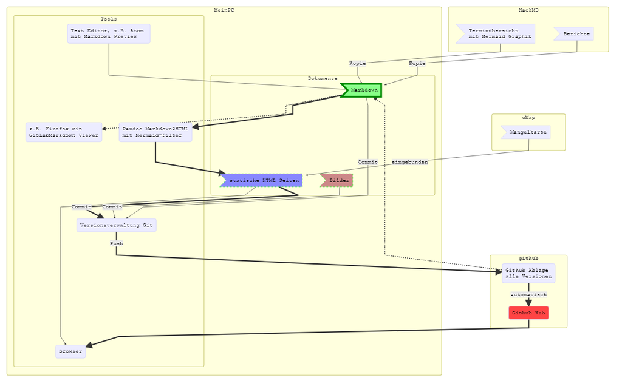

## Web-Seiten Generierung für https://adfc-hemmingen-pattensen.github.io/

Der Dreh- und Angelpunkt sind unformatierte Textseiten die im der [Markdown](https://daringfireball.net/projects/markdown/) Sprache geschrieben sind. Präziser im Dialekt *[“GitLab Flavored Markdown” (GFM)](https://docs.gitlab.com/ee/user/markdown.html)*.

Ein Markdown Beipiel:

```
#Markdown Überschrift
Der *schräge* Fuchs springt über den **fetten** Hund.
> Das ist kein Zitat

Eine Liste
* Punkt A
* Punkt B
* ![Ein Bild](https://www.adfc.de/static/images/logo_adfc.gif)

--------------------------------------------------------------
```

sieht dann später so aus:

### Markdown Überschrift

Der *schräge* Fuchs springt über den **fetten** Hund.

> Das ist kein Zitat

Eine Liste

- Punkt A
- Punkt B

Diese Seiten mit der Dateiendung **.md** werden mit dem Software Programm [PanDoc](https://pandoc.org/) in HTML Seiten konvertiert. Dieses geschieht auf der Kommando Zeile mit dem Befehl

```
pandoc seite.md -o seite.html #-o steht für Output
```

Zusammen mit den gespeicherten Bildern wird das ganze Verzeichnis mit dem Software Programm [Git](https://git-scm.com/) zuerst auf dem PC in eine Versionsablage kopiert (commit) und anschließend auf den [Github Server](https://github.com/adfc-hemmingen-pattensen/adfc-hemmingen-pattensen.github.io) geschoben (push). Hier befindet sich also eine komplette Kopie aller Versionen.

Der Github Server stellt anschließend die HTML und Bilder Dateien auf seinen [Webserver](https://adfc-hemmingen-pattensen.github.io/) unter der URL https://adfc-hemmingen-pattensen.github.io/ als Webseiten öffentlich zur Verfügung.

### Nicht ohne Netz und doppelten Boden.

Das gute daran, die Dateien von dem [Github Server](https://github.com/adfc-hemmingen-pattensen/adfc-hemmingen-pattensen.github.io) kann jeder “klonen”, er hat dann die gleichen Dateien auf seinen Rechner. Er kann auch Änderungen wieder “pushen”, aber nur der Besitzer des Passwortes 😁 kann die Änderungen für die Öffentlichkeit freigeben. Oder anders gesagt, auch ich kann die Dateien, im Notfall, wieder bekommen.

### Extras

#### Mängelkarte

Für unsere [Mängelkarte](https://adfc-hemmingen-pattensen.github.io/MaengelHemPat.html) benutze ich den [umap](https://umap.openstreetmap.fr/de/) Service. Die Karten werden direkt mithilfe des Browser auf den [umap](https://umap.openstreetmap.fr/de/) Server erstellt und bleiben dort liegen. Mithilfe des HTML *iFrame* Befehls wird unsere umap WebSeite im Browser des Betrachter eingebunden.

#### Terminübersicht und Tourenbeschreibungen

Für die [Terminübersicht](https://hackmd.io/U-6kWHTpRAyp9glY_QNyKg?both#) und [Tourenbeschreibungen](https://hackmd.io/7JqXva29Si2VjOouL6VJxQ?both#) benutzen wir den [HackMD](https://hackmd.io/) Service. Dieses ist ein Online Markdown Editor mit einem eingebauten Markdown Betrachter (Pre-view). Jeder der die Links besitzt kann die Seiten ändern und erweitern. Die Inhalte dieser Seiten kopiere ich bei Bedarf manuell in unsere Markdown Seiten.

> An eine teilweise automatische Einbindung von Inhalten, wie z.B. Toureneinladungen, ähnlich wie bei [umap](https://umap.openstreetmap.fr/de/) wird noch gearbeitet. (Stand 2018-04-20-Fri)

##### Grafiken

Sowohl [HackMD](https://hackmd.io/) als auch [PanDoc](https://pandoc.org/), zusammen mit einem mermaid-filter, unterstützen die Grafiksprache [mermaid](https://mermaidjs.github.io/). Ähnlich wie bei der Markdown Sprache besteht auch hier die Beschreibung und Formatierung rein aus unformatierten Texten.

Aus:

````
```mermaid
graph TD;
    A-->B;
    A-->C;
    B-->D;
```
````

wird:

[figure not shown]

### Werkzeuge

[Markdown](https://daringfireball.net/projects/markdown/) lässt sich mit jedem Text Editor schreiben. Aber ähnlich wie bei [HackMD](https://hackmd.io/), ist der [Atom](https://atom.io/) Editor, mit den Zusatzpaketen markdown-preview-enhanced und atom-mermaid der Editor meiner Wahl.

Für das schnelle Prüfen den `nackten` Markdown Seiten gibt es das [Firefox](https://www.mozilla.org/en-US/firefox/new/) Add-on [GitLab Markdown Viewer](https://github.com/painyeph/GitLabMarkdownViewer). Dann kann man sich *.md Dateien direkt im Browser ansehen.